# R Notebook

```r
library(tidyverse)
library(janitor)
library(infer)
```

```r
nice <- read_csv("data_2/nice.csv")
algarve <- read_csv("data_2/algarve.csv")
corfu <- read_csv("data_2/corfu.csv")
florence <- read_csv("data_2/florence.csv")
```

##Independent sample (not related) > is the mean price of lets in the Algarve significantly higher than mean price in Nice

NULL hypothesis: mean price of lets in the Algarve are NOT significantly higher than Nice H_0: = \

Alternative hypothesis: mean price of lets in the Algarve ARE significantly higher than Nice H_1: > \

[figure not shown]

```r
null_distribution
```

```
Response: price (numeric)
Explanatory: location (factor)
Null Hypothesis: independence
```

| replicate | stat |
| --- | --- |
| 1 | -77.7666667 |
| 2 | 22.1500000 |
| 3 | -1.1833333 |
| 4 | 2.1916667 |
| 5 | 2.5666667 |
| 6 | -79.9750000 |
| 7 | -90.3500000 |
| 8 | 92.2333333 |
| 9 | 114.0250000 |
| 10 | -29.6416667 |

[output cut: 990 more lines]

```r
observed_stat
```

```
Response: price (numeric)
Explanatory: location (factor)
```

| stat |
| --- |
| 251.4 |

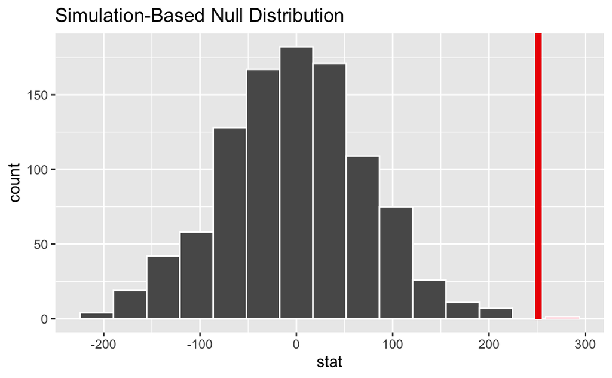

```r
null_distribution %>%
  visualise()+
  shade_p_value(obs_stat = observed_stat, direction = "greater")
```

[output not shown]

The price is significantly different as p_value (0.001) < 0.5, therefore we reject null hypothesis

#Task

alpha = 0.05, null hypothesis: price in florence is not significantly different from Corfu alternative hypothesis: price in florence is significantly less than Corfu

```r
 florence_corfu_prices <- bind_rows(florence = florence,
                                    corfu = corfu,
                                    .id = "location")
florence_corfu_prices %>%
  filter(location == "florence") %>%
  ggplot(aes(x = price))+
  geom_histogram(bins = 15,
                 col = "white")

florence_corfu_prices %>%
  filter(location == "corfu") %>%
  ggplot(aes(x = price))+
  geom_histogram(bins = 15,
                 col = "white")

null_distribution <- florence_corfu_prices %>%
  specify(response = price, explanatory = location) %>%
  hypothesise(null = "independence") %>%
  generate(reps = 1000, type = "permute") %>%
  calculate(stat = "diff in means", order = c("florence", "corfu"))

observed_stat <- florence_corfu_prices %>%
  specify(response = price, explanatory = location) %>%
  calculate(stat = "diff in means", order = c("florence", "corfu"))

null_distribution %>%
  visualise()+
  shade_p_value(obs_stat = observed_stat, direction = "left")

p_value <- null_distribution %>%
  get_p_value(obs_stat = observed_stat, direction = "left")
```

[output not shown]

##Paired / dependent sample

| year | term | subject | subject_abbr | course | course_num | course_numeric | seminar | ind_study | apprenticeship | internship | honors_contracts | laboratory | special_topic | textbook_isbn | bookstore_new | bookstore_used | amazon_new | amazon_used | notes |
| --- | --- | --- | --- | --- | --- | --- | --- | --- | --- | --- | --- | --- | --- | --- | --- | --- | --- | --- | --- |
| 2.018000e+03 | Fall | American Indian Studies | AM IND | Introduction to American Indian Studies | M10 | 10 | FALSE | FALSE | FALSE | FALSE | FALSE | FALSE | FALSE | 9.781138e+12 | 47.97 | 44.97 | 47.45 | 51.20 | NA |
| 2.018000e+03 | Fall | Anthropology | ANTHRO | Archaeology: Introduction | 2 | 2 | FALSE | FALSE | FALSE | FALSE | FALSE | FALSE | FALSE | 9.780308e+12 | 14.26 | 10.96 | 13.55 | 7.10 | NA |
| 2.018000e+03 | Fall | Art | NA | New Genres | 11D | 11 | FALSE | FALSE | FALSE | FALSE | FALSE | FALSE | FALSE | NA | NA | NA | NA | NA | NA |
| 2.018000e+03 | Fall | Arts and Architecture | ART&ARC | Arts Encounters: Exploring Arts Literacy in 21st Century | 10 | 10 | FALSE | FALSE | FALSE | FALSE | FALSE | FALSE | FALSE | 9.780980e+12 | 13.50 | 11.00 | 12.53 | NA | NA |
| 2.018000e+03 | Fall | Asian | NA | Introduction to Buddhism | M60W | 60 | FALSE | FALSE | FALSE | FALSE | FALSE | FALSE | FALSE | 9.780200e+12 | 49.26 | 43.26 | 54.95 | 24.83 | NA |
| 2.018000e+03 | Fall | Astronomy | ASTR | Black Holes and Cosmic Catastrophes | 4 | 4 | FALSE | FALSE | FALSE | FALSE | FALSE | FALSE | FALSE | 9.780134e+12 | 119.97 | 67.00 | 124.80 | 47.75 | NA |
| 2.018000e+03 | Fall | Biomedical Research | BMD RES | Biomedical Research: Concepts and Strategies | 5HA | 5 | FALSE | FALSE | FALSE | FALSE | FALSE | FALSE | FALSE | NA | NA | NA | NA | NA | NA |
| 2.018000e+03 | Fall | Chemistry and Biochemistry | CHEM | Atomic and Molecular Structure, Equilibria, Acids, and Bases | 14A | 14 | FALSE | FALSE | FALSE | FALSE | FALSE | FALSE | FALSE | 9.781319e+12 | 188.10 | 149.00 | NA | NA | NA |
| 2.018000e+03 | Fall | Chemistry and Biochemistry | CHEM | Thermodynamics, Electrochemistry, Kinetics, and Organic Chemistry | 14B | 14 | FALSE | FALSE | FALSE | FALSE | FALSE | FALSE | FALSE | 9.781319e+12 | 215.75 | 162.00 | NA | 90.00 | New version only from resellers |
| 2.018000e+03 | Fall | Chicana and Chicano Studies | CHICANO | Elementary Nahuatl | M5A | 5 | FALSE | FALSE | FALSE | FALSE | FALSE | FALSE | FALSE | NA | NA | NA | NA | NA | NA |

[output cut: 191 more lines]

> is there a significant difference on average between prices for new texts offered by campus bookstore vs the same book on amazon

Null: there is not a significant difference on avg between bookstore - amazon Alternative :there is a significant difference on avg between bookstore - amazon

| year | term | subject | subject_abbr | course | course_num | course_numeric | seminar | ind_study | apprenticeship | internship | honors_contracts | laboratory | special_topic | textbook_isbn | bookstore_new | bookstore_used | amazon_new | amazon_used | notes | diff_new |
| --- | --- | --- | --- | --- | --- | --- | --- | --- | --- | --- | --- | --- | --- | --- | --- | --- | --- | --- | --- | --- |
| 2018 | Fall | American Indian Studies | AM IND | Introduction to American Indian Studies | M10 | 10 | FALSE | FALSE | FALSE | FALSE | FALSE | FALSE | FALSE | 9.781138e+12 | 47.97 | 44.97 | 47.45 | 51.20 | NA | 0.52 |
| 2018 | Fall | Anthropology | ANTHRO | Archaeology: Introduction | 2 | 2 | FALSE | FALSE | FALSE | FALSE | FALSE | FALSE | FALSE | 9.780308e+12 | 14.26 | 10.96 | 13.55 | 7.10 | NA | 0.71 |
| 2018 | Fall | Arts and Architecture | ART&ARC | Arts Encounters: Exploring Arts Literacy in 21st Century | 10 | 10 | FALSE | FALSE | FALSE | FALSE | FALSE | FALSE | FALSE | 9.780980e+12 | 13.50 | 11.00 | 12.53 | NA | NA | 0.97 |
| 2018 | Fall | Asian | NA | Introduction to Buddhism | M60W | 60 | FALSE | FALSE | FALSE | FALSE | FALSE | FALSE | FALSE | 9.780200e+12 | 49.26 | 43.26 | 54.95 | 24.83 | NA | -5.69 |
| 2018 | Fall | Astronomy | ASTR | Black Holes and Cosmic Catastrophes | 4 | 4 | FALSE | FALSE | FALSE | FALSE | FALSE | FALSE | FALSE | 9.780134e+12 | 119.97 | 67.00 | 124.80 | 47.75 | NA | -4.83 |
| 2018 | Fall | Communication | COMM | Introduction to Communication Studies | 10 | 10 | FALSE | FALSE | FALSE | FALSE | FALSE | FALSE | FALSE | 9.780200e+12 | 16.95 | 12.75 | 11.77 | 5.41 | NA | 5.18 |
| 2018 | Fall | Comparative Literature | COM LIT | Survey of Literature: Age of Enlightenment to 20th Century | 2CW | 2 | FALSE | FALSE | FALSE | FALSE | FALSE | FALSE | FALSE | 9.780376e+12 | 11.96 | 9.96 | 10.87 | 6.75 | NA | 1.09 |
| 2018 | Fall | Dance | NA | Beginning Martial Arts | 10 | 10 | FALSE | FALSE | FALSE | FALSE | FALSE | FALSE | FALSE | 9.780982e+12 | 26.75 | 20.25 | 38.94 | NA | NA | -12.19 |
| 2018 | Fall | English | ENGL | UCLA Centennial Initiative: Burning Books--UCLA, Fahrenheit 451, and Politics of Libraries | 19 | 19 | FALSE | FALSE | FALSE | FALSE | FALSE | FALSE | FALSE | 9.781452e+12 | 9.96 | 8.96 | 8.99 | NA | NA | 0.97 |
| 2018 | Fall | English Composition | ENGCOMP | Intermediate Composition for Multilingual Students | 1A | 1 | FALSE | FALSE | FALSE | FALSE | FALSE | FALSE | FALSE | 9.781109e+12 | 39.97 | 32.97 | 35.00 | 34.30 | NA | 4.97 |

[output cut: 58 more lines]

| p_value |
| --- |
| 0.034 |

Our study suggests that the prices in the bookshop are significantly different from the prices on amazon on avg (p = 0.034 < alpha of 0.05)

#Are prices lower on amazon? (reframe)

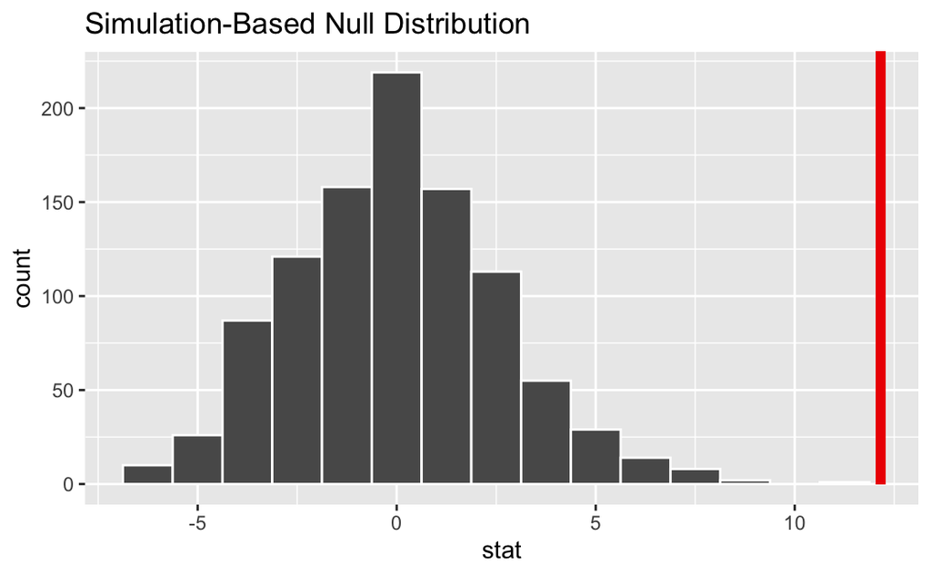